# Transformasi

Weksi Budiaji, Agung Satrio Wicaksono

2025-09-17

# Transformasi ERD ke Tabel

## 1. Pendahuluan

Transformasi dari **Entity Relationship Diagram (ERD)** ke dalam **tabel relasional** merupakan tahap penting dalam perancangan basis data. Proses ini bertujuan untuk mengubah konsep konseptual (ERD) menjadi bentuk logis (tabel) yang dapat diimplementasikan dalam sistem manajemen basis data (DBMS).

Dalam materi ini, kita akan membahas aturan umum transformasi dan bagaimana setiap jenis atribut dalam ERD dipetakan ke tabel.

## 2. Aturan Umum Transformasi ERD ke Tabel

Ada beberapa aturan dasar yang perlu diingat ketika mentransformasi ERD menjadi tabel:

1. **Setiap entitas → satu tabel** Jika ada tiga entitas dalam ERD, maka akan terbentuk tiga tabel yang sesuai.
2. **Setiap atribut → kolom dalam tabel** Jumlah atribut pada entitas akan sama dengan jumlah kolom dalam tabel.
   - Kolom pertama biasanya ditempati oleh **primary key**.
   - Urutan atribut selain primary key bisa disesuaikan dengan kepentingan informasi.
3. **Kardinalitas relasi memengaruhi tabel** Kardinalitas (satu-ke-satu, satu-ke-banyak, atau banyak-ke-banyak) akan menentukan:
   - Apakah cukup menambahkan foreign key.
   - Atau perlu membuat tabel baru khusus untuk relasi.

## 3. Transformasi Entitas menjadi Tabel

### 3.1 Contoh Entitas Mahasiswa

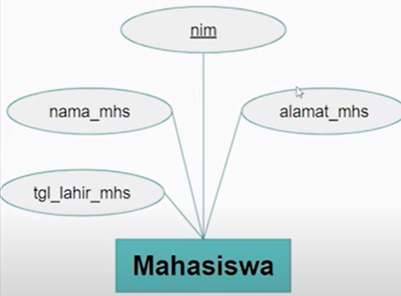

ERD Mahasiswa

Jika entitas **Mahasiswa** memiliki atribut:

- NIM (Primary Key)
- Nama
- Alamat
- Tanggal Lahir

Maka tabel yang terbentuk adalah:

| NIM | Nama | Alamat | Tanggal_Lahir |
| --- | --- | --- | --- |
| 3330824100 | xyz | cilegon | 01-01-2008 |
| 3330824102 | abc | palembang | 12-05-2008 |
| 3330824103 | pqr | pontianak | 27-10-2008 |

### 3.2 Contoh Entitas Mata Kuliah

Entitas **Mata Kuliah** dengan atribut:

- Kode_MK (Primary Key)
- Nama_MK
- SKS
- Semester

Akan ditransformasi menjadi tabel:

| Kode_MK | Nama_MK | SKS | Semester |
| --- | --- | --- | --- |
| STA623211 | Basis data | 3 | 3 |
| STA623205 | Analisis regresi | 3 | 3 |
| STA623209 | Analisis regresi | 3 | 3 |

## 4. Transformasi Atribut Khusus

Selain atribut sederhana, ada beberapa jenis atribut yang perlu perlakuan khusus.

### 4.1 Atribut Turunan

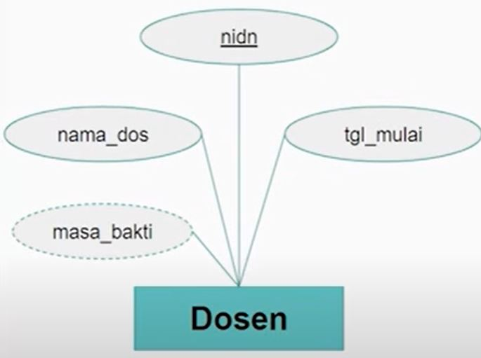

ERD Dosen

Atribut turunan adalah atribut yang nilainya dapat dihitung dari atribut lain. Contoh: **Masa Bakti** dapat dihitung dari *Tanggal Mulai Kerja*.

Namun, dalam tabel, atribut turunan **tetap diberikan kolom tersendiri**:

| NIDN | Nama | Tanggal_Mulai | Masa_Bakti |
| --- | --- | --- | --- |
| 001 | abc | 01-01-2020 | 5 |
| 002 | pqr | 23-04-2021 | 4 |
| 030 | xyz | 15-07-2023 | 2 |

### 4.2 Atribut Multivalued (Bernilai Banyak)

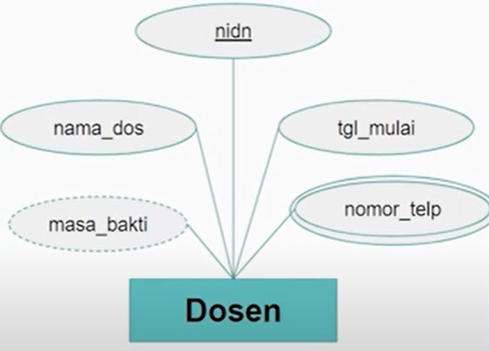

ERD dengan Multivalued Atribute

Atribut multivalued berarti satu entitas bisa memiliki banyak nilai untuk atribut tersebut. Contoh: **Nomor Telepon** pada entitas **Dosen**.

Solusi:

- Buat tabel baru khusus untuk atribut multivalued.
- Tabel baru tersebut menyertakan primary key dari tabel induk sebagai **foreign key**.

Contoh:

| NIDN | Nama | Tanggal_Mulai | Masa_Bakti |
| --- | --- | --- | --- |
| 001 | abc | 01-01-2020 | 5 |
| 002 | pqr | 23-04-2021 | 4 |
| 030 | xyz | 15-07-2023 | 2 |

| NIDN | Nomor_Telpon |
| --- | --- |
| 001 | 08884356741 |
| 001 | 08534356731 |
| 002 | 08724356711 |

### 4.3 Atribut Komposit

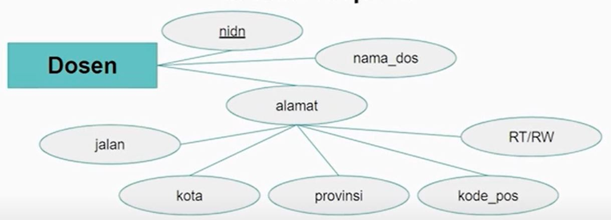

ERD dengan Composite Atribute

Atribut komposit dapat dipecah menjadi beberapa bagian yang lebih kecil. Contoh: **Alamat** terdiri atas *Jalan, Kota, Provinsi, Kode Pos, RT/RW*.

Maka, tabel akan menyimpan bagian-bagian atribut tersebut, bukan kolom “Alamat” tunggal.

| NIDN | Nama | Jalan | Kota | Provinsi | Kode_Pos | RT_RW |
| --- | --- | --- | --- | --- | --- | --- |
| 001 | abc | Jl. DIponegoro | cilegon | Banten | 421413 | 5 |
| 002 | pqr | Jl. DJuanda | Bogor | Jawa Barat | 421742 | 3 |
| 030 | xyz | Jl. Hatta | Jakarta Utara | DKI Jakarta | 147462 | 2 |

## 5. Representasi

### 5.1 Relasi Satu ke Satu

Relasi **1:1** direpresentasikan dengan cara **menambahkan atribut foreign key (FK)** ke dalam salah satu tabel yang terlibat. Foreign key ini berasal dari **primary key** tabel pasangannya.

Contoh sederhana:

- Entitas 1 → Tabel 1 dengan primary key PK1
- Entitas 2 → Tabel 2 dengan primary key PK2
- Relasi 1:1 → tambahkan PK2 sebagai FK di Tabel 1, atau PK1 sebagai FK di Tabel 2.

Relasi: Seorang dosen dapat mengetuai satu program studi, dan setiap program studi harus memiliki seorang ketua.

Ada dua pilihan:

- FK di tabel Dosen → menambahkan atribut Kode_PS di tabel Dosen. Kekurangan: Banyak dosen tidak menjadi ketua program studi → banyak kolom kosong.
- FK di tabel Program Studi → menambahkan atribut NIDN di tabel Program Studi. Kelebihan: Setiap program studi pasti memiliki ketua → semua data akan terisi.

Karena dari sisi Dosen ada kemungkinan tidak menjadi ketua (**derajat minimum = 0**), sedangkan setiap Program Studi harus memiliki ketua (**derajat minimum = 1**), maka foreign key sebaiknya ditempatkan pada **tabel Program Studi**.

Hasil transformasi:

Tabel Dosen

| NIDN | Nama | Tanggal_Lahir | Alamat |
| --- | --- | --- | --- |
| 001 | Abc | 01-01-1989 | Cilegon |
| 002 | Pqr | 25-05-1991 | Serang |
| 030 | Xyz | 12-11-1979 | Jakarta |

Tabel Program Studi

| Kode_PS | Nama_PS | NIDN_FK |
| --- | --- | --- |
| PS01 | Informatika | 001 |
| PS02 | Statistika | 030 |

Aturan Penempatan Foreign Key dalam Relasi 1:1 dengan melihat derajat relasi minimum pada masing-masing entitas. Jika salah satu entitas memiliki minimum = 0 (tidak selalu berelasi), lebih baik FK ditempatkan pada entitas dengan minimum = 1. Jika keduanya memiliki derajat minimum sama, maka FK ditempatkan pada tabel yang memiliki jumlah baris lebih sedikit (ukuran tabel lebih kecil).

### 5.2 Relasi Satu ke Banyak (1:N)

Relasi 1:N direpresentasikan dengan membuat Primary key dari entitas yang **berderajat 1** → menjadi foreign key di tabel entitas yang berderajat N. Dengan demikian, entitas di sisi **“banyak” (N)** dapat menyimpan informasi keterkaitan dengan entitas di sisi “satu” (1).

Contoh Dosen dan Kelas dengan entitas Dosen yaitu NIDN (PK), Nama, Alamat, dan Tanggal_Lahir. Pada entitas Kelas terdapat Kode_Kelas (PK), Lokasi. Relasi yang terjadi adalah satu dosen dapat mengajar banyak kelas dan satu kelas hanya diajar oleh satu dosen.

Transformasi:

Primary key NIDN dari entitas Dosen ditambahkan ke tabel Kelas sebagai foreign key.

Hasil transformasi:

Tabel Dosen

| NIDN | Nama | Tanggal_Lahir | Alamat |
| --- | --- | --- | --- |
| 001 | Abc | 01-01-1989 | Cilegon |
| 002 | Pqr | 25-05-1991 | Serang |
| 030 | Xyz | 12-11-1979 | Jakarta |

Tabel Kelas

| Kode_Kelas | Lokasi | NIDN_FK |
| --- | --- | --- |
| K01 | Gedung A | 001 |
| K02 | Gedung U | 002 |

Prinsip Dasar Penempatan Foreign Key pada Relasi 1:N yaitu FK ditempatkan di sisi **“N” (banyak)**. Hal ini mencegah duplikasi data dan memudahkan representasi hubungan. Dengan cara ini, setiap baris di tabel entitas “banyak” akan berelasi tepat dengan satu baris di tabel entitas “satu”.

### 5.3 Relasi N ke N

Salah satu jenis hubungan yang umum adalah relasi N ke N (many-to-many), di mana satu entitas dapat berhubungan dengan banyak entitas lain. Dan entitas lain tersebut juga dapat berhubungan dengan banyak entitas yang pertama.

Contoh umum:

- Mahasiswa mengambil banyak mata kuliah, dan setiap mata kuliah bisa diambil oleh banyak mahasiswa.
- Dosen membimbing banyak mahasiswa, dan mahasiswa bisa dibimbing oleh lebih dari satu dosen.

Relasi **N ke N** tidak bisa diwakili hanya dengan penambahan foreign key, karena akan menimbulkan **multivalue attribute**. Oleh karena itu, langkah transformasinya adalah:

1. Setiap entitas diubah menjadi tabel.
2. Buat tabel baru khusus untuk relasi. 3, Isi tabel relasi dengan:
- Foreign key dari entitas pertama.
- Foreign key dari entitas kedua.
- Atribut relasi (jika ada).

Contoh pada relasi Mahasiswa dengan Mata Kuliah.

Entitas Mahasiswa (Tabel Mahasiswa)

- Atribut: NIM (PK), Nama, Alamat, Tgl_Lahir

Entitas Mata Kuliah (Tabel MataKuliah)

- Atribut: Kode_MK (PK), Nama_MK, SKS, Semester

Relasi: Mempelajari (N ke N) (pembuatan tabel baru)

- Atribut relasi: Nilai
- Dibuat tabel baru: Nilai
- Isi kolom: NIM (FK), Kode_MK (FK), Nilai.

Hasil transformasi:

Tabel Mahasiswa

| NIM | Nama | Alamat | Tanggal_Lahir |
| --- | --- | --- | --- |
| 3330824100 | xyz | cilegon | 01-01-2008 |
| 3330824102 | abc | palembang | 12-05-2008 |
| 3330824103 | pqr | pontianak | 27-10-2008 |

Tabel Mata Kuliah

| Kode_MK | Nama_MK | SKS | Semester |
| --- | --- | --- | --- |
| STA623211 | Basis data | 3 | 3 |
| STA623205 | Analisis regresi | 3 | 3 |
| STA623209 | Komputasi Statistika | 3 | 3 |

Tabel Nilai

| NIM | Kode_MK | Nilai |
| --- | --- | --- |
| 3330824100 | STA623211 | 89 |
| 3330824100 | STA623209 | 95 |
| 3330824102 | STA623211 | 90 |

## 6. Tambahan

### 6.1 Entitas Lemah ke Tabel

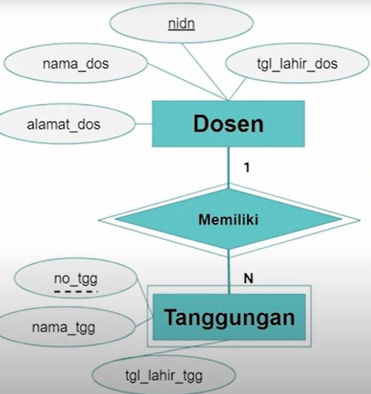

ERD dengan Entitas Lemah

Dalam perancangan basis data menggunakan Entity Relationship Diagram (ERD), kita mengenal dua jenis entitas:

- Entitas kuat (strong entity) → entitas yang dapat berdiri sendiri dan memiliki atribut kunci (primary key) yang unik.
- Entitas lemah (weak entity) → entitas yang keberadaannya bergantung pada entitas kuat, sehingga tidak bisa memiliki primary key sendiri tanpa menyertakan primary key dari entitas kuat yang berelasi dengannya.

Karakteristik Entitas Lemah yaitu digambarkan dengan kotak bergaris ganda pada ERD dan selalu berelasi dengan entitas kuat (digambarkan dengan kotak bergaris tunggal). Relasi antara entitas lemah dan entitas kuat ditunjukkan dengan belah ketupat bergaris ganda. Entitas lemah tidak memiliki primary key yang berdiri sendiri, melainkan menggunakan primary key dari entitas kuat yang berelasi dengannya.

Aturan transformasi entitas lemah ke tabel berbeda dengan entitas kuat. Entitas kuat menggunakan tabel biasa yaitu setiap atribut dari entitas kuat menjadi kolom dan rimary key diletakkan di kolom pertama. Kebalikannya, entitas lemah memerlukan tabel tersendiri dengan tribut-atribut dari entitas lemah menjadi kolom tabel. Primary key entitas kuat ditambahkan ke tabel entitas lemah. Primary key dari entitas lemah biasanya berupa gabungan antara primary key entitas kuat dan **partial key** dari entitas lemah (jika ada) sehingga Primary key entitas kuat menjadi foreign key sekaligus bagian dari primary key tabel entitas lemah.

Hasil transformasi:

Tabel Dosen

| NIDN | Nama | Tanggal_Lahir | Alamat |
| --- | --- | --- | --- |
| 001 | Abc | 01-01-1989 | Cilegon |
| 002 | Pqr | 25-05-1991 | Serang |
| 030 | Xyz | 12-11-1979 | Jakarta |

Tabel Tanggungan

| NIDN | Nama_Tanggungan | Hubungan |
| --- | --- | --- |
| 001 | Abc | Istri |
| 001 | Pqr | Anak |
| 001 | Xyz | Anak |

NIDN diambil dari entitas Dosen dan berfungsi sebagai foreign key yang merujuk ke tabel Dosen. Jika seorang dosen (NIDN) dihapus dari tabel Dosen, maka seluruh data tanggungannya juga akan hilang. Hal ini sesuai dengan sifat entitas lemah yang keberadaannya **bergantung penuh** pada entitas kuat.

### 6.2 Sub Entitas (Spesialisasi & Generalisasi) ke dalam Tabel

Dalam perancangan basis data, terdapat konsep spesialisasi dan generalisasi. Generalisasi adalah proses menggabungkan beberapa entitas khusus menjadi entitas yang lebih umum. Spesialisasi adalah kebalikannya, yaitu memecah entitas umum menjadi entitas khusus (sub entitas).

Sub entitas diperlakukan mirip dengan entitas lemah, karena tidak memiliki primary key sendiri. Primary key dari entitas general (induk) akan diturunkan dan digunakan juga sebagai primary key pada tabel sub entitas. Tabel sub entitas hanya menambahkan atribut khusus yang membedakan tiap sub entitas. Dengan cara ini, hubungan antara entitas umum dan sub entitasnya tetap terjaga.

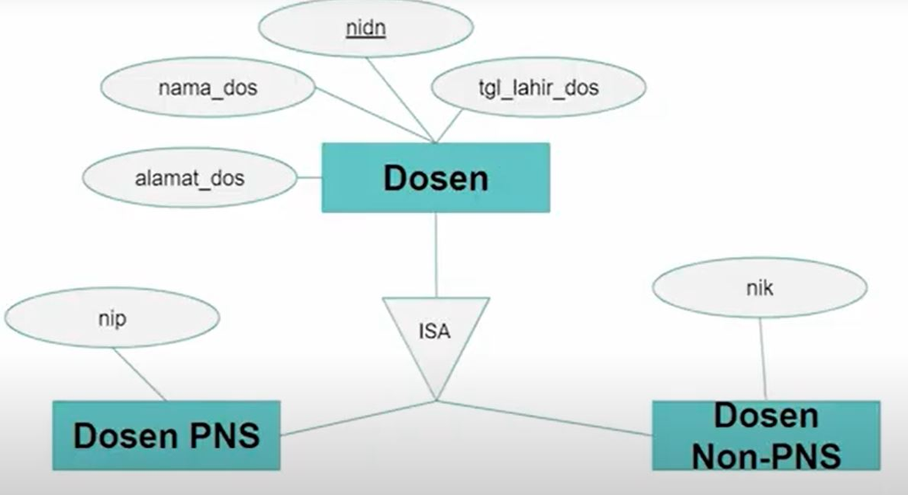

ERD dengan Sub Entitas

Studi Kasus pada Entitas Dosen. Entitas General yaitu Dosen. Entitas Dosen sebagai entitas umum memiliki atribut: nidn (primary key), nama_dosen, alamat tanggal_lahir. Pada sub Entitas terdapat Dosen PNS dan Dosen Non-PNS. Dosen PNS memiliki atribut tambahan nip sedangkan Dosen Non-PNS memiliki atribut tambahan nik. Kedua sub entitas tersebut mewarisi atribut kunci nidn dari entitas general Dosen.

Tabel Dosen

| nidn | nama_dosen | alamat | tanggal_lahir |
| --- | --- | --- | --- |
| 01 | Andi | Jakarta | 1980-05-12 |
| 02 | Budi | Bandung | 1990-08-20 |

Tabel Dosen PNS

| nidn | nip |
| --- | --- |
| 01 | 1980123456 |

Tabel Dosen Non PNS

| nidn | nik |
| --- | --- |
| 02 | 1990123456 |

### 6.3 Relasi Tunggal ke dalam Tabel

#### 6.3.1 Relasi Tunggal 1 ke N

Dalam relasi tunggal 1 ke N, sebuah entitas dapat berhubungan dengan beberapa entitas lain yang masih berasal dari himpunan entitas yang sama. Aturan Transformasi ke Tabel:

1. Primary key dari entitas digunakan dua kali dengan fungsi yang berbeda:
- Sebagai primary key entitas itu sendiri.
- Sebagai foreign key yang menunjuk ke entitas lain dalam himpunan yang sama.
2. Foreign key diberi nama berbeda agar tidak membingungkan.

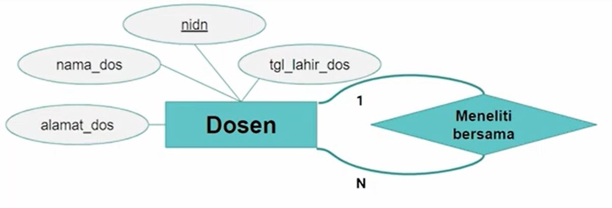

ERD dengan Unary relationship 1:N

Contoh Kasus: Dosen Meneliti Bersama Dosen. Relasi, Meneliti Bersama (satu dosen dapat menjadi ketua penelitian dan memiliki beberapa dosen anggota).

| NIDN | Nama | Tanggal_Lahir | Alamat | NIDN_Peneliti |
| --- | --- | --- | --- | --- |
| 01 | Dosen A | 01-01-1980 | Malang | 03 |
| 01 | Dosen A | 01-01-1980 | Malang | 04 |
| 02 | Dosen B | 02-02-1982 | Surabaya | 01 |
| 02 | Dosen B | 02-02-1982 | Surabaya | 03 |

Interpretasi: Dosen 01 meneliti bersama dosen 03 dan 04. Dosen 02 meneliti bersama dosen 01 dan 03.

#### 6.3.2 Relasi Tunggal N ke N

Dalam relasi N ke N, banyak entitas dapat berhubungan dengan banyak entitas lain dalam himpunan yang sama. Aturan Transformasi ke Tabel yaitu dibuat tabel baru untuk mewakili relasi yang berisi

- Primary key dari entitas yang berelasi.
- Atribut tambahan dari relasi jika ada.

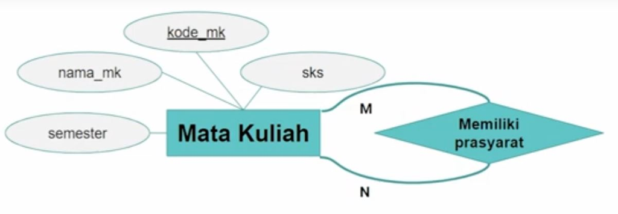

ERD dengan Unary relationship N:N

Contoh Kasus: Mata Kuliah dengan Prasyarat. Relasinya yaitu Prasyarat (satu mata kuliah dapat memiliki banyak prasyarat, dan satu mata kuliah dapat menjadi prasyarat untuk banyak mata kuliah lain).

Tabel Prasyarat

| Kode_MK | Kode_MK_Syarat |
| --- | --- |
| 001 | 035 |
| 001 | 025 |
| 002 | 001 |

Interpretasi: Mata kuliah 001 memiliki prasyarat 035 dan 025. Mata kuliah 002 memiliki prasyarat 001.

### 6.4 Relasi Ganda ke dalam Tabel

Relasi ganda dalam basis data adalah kondisi ketika sebuah entitas atau himpunan entitas memiliki lebih dari satu relasi dengan entitas lain. Dalam penerapannya ke tabel, relasi ganda tidak langsung diproses sebagai satu kesatuan, melainkan ditinjau secara terpisah. Artinya, setiap relasi dianggap sebagai relasi tunggal, kemudian diimplementasikan ke tabel sesuai derajat relasi masing-masing.

Prinsip Dasar Implementasi Relasi Ganda, langkah-langkahnya hampir sama dengan relasi biasa, yaitu:

1. Identifikasi entitas dan atribut → setiap entitas dibuatkan tabel dengan atributnya.
2. Identifikasi relasi pertama → tentukan apakah relasi memiliki atribut tambahan dan derajat relasinya (1–N, M–N).
3. Implementasikan relasi pertama ke tabel → tambahkan foreign key atau buat tabel baru jika diperlukan.
4. Lanjutkan ke relasi berikutnya → gunakan tabel hasil implementasi sebelumnya sebagai dasar.

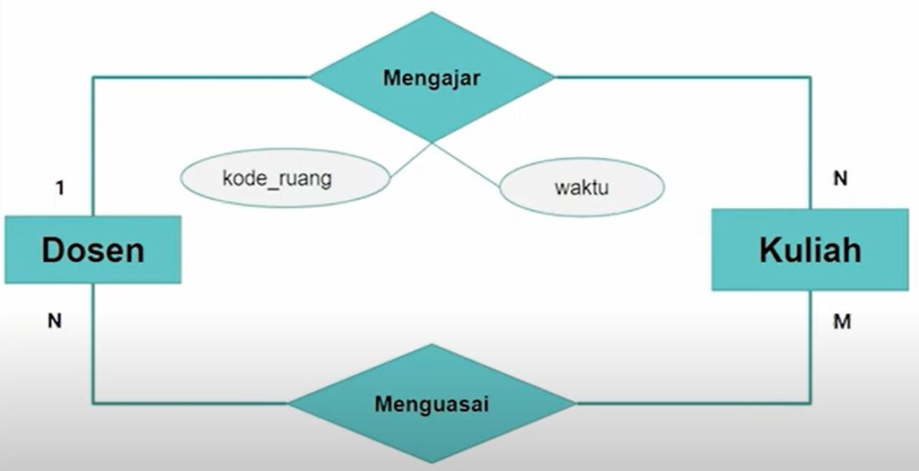

ERD dengan Binary relationship

Contoh Studi Kasus: Relasi Dosen dan Kuliah.

Relasi Pertama: Mengajar (1–N)

Relasinya: Satu dosen mengajar banyak kuliah. Implementasi ke tabel:

- Tabel Dosen menyimpan nidn sebagai primary key.
- Tabel Kuliah menyimpan kode_MK sebagai primary key, serta nidn sebagai foreign key untuk menunjukkan dosen pengajarnya.

Tabel Dosen

| NIDN | Nama | Tanggal_Lahir | Alamat |
| --- | --- | --- | --- |
| 01 | Dosen A | 01-01-1980 | Malang |
| 02 | Dosen B | 02-02-1982 | Surabaya |

Tabel Kuliah

| Kode_MK | Nama_MK | Ruang | Waktu | NIDN |
| --- | --- | --- | --- | --- |
| STA623211 | Basis data | U.3 | 07.30-10.00 | 01 |
| STA623205 | Analisis regresi | CO.3 | 13.00-15.30 | 02 |
| STA623209 | Komputasi Statistika | U.3 | 10.00-12.30 | 01 |

Relasi Kedua: Menguasai (M–N)

Relasinya: Banyak dosen menguasai banyak mata kuliah. Karena ini adalah relasi M–N, maka perlu tabel baru. Tabel Menguasai dibentuk dengan atribut:

- nidn (foreign key dari tabel Dosen)
- kode_kuliah (foreign key dari tabel Kuliah)

Tabel Menguasai

| NIDN | Kode_MK |
| --- | --- |
| 01 | STA623211 |
| 01 | STA623209 |
| 02 | STA623205 |

### 6.5 Relasi Ternary ke dalam Tabel

Dalam perancangan basis data, seringkali kita menjumpai relasi yang melibatkan lebih dari dua entitas. Relasi seperti ini disebut n-ary relation, di mana salah satu bentuknya adalah ternary relation yang melibatkan tiga entitas. Contoh kasusnya adalah relasi antara Dosen – Mata Kuliah – Kelas. Seorang dosen mengajar mata kuliah, mata kuliah tersebut diajarkan di kelas tertentu, dan setiap kelas memiliki keterkaitan dengan dosen serta mata kuliah.

Prinsip Transformasi Relasi Ternary yaitu relasi ternary tidak langsung diterapkan ke tabel dalam bentuk tiga arah. Prinsip utamanya adalah Relasi ternary diubah menjadi beberapa relasi biner. Dengan cara ini, setiap entitas akan tetap saling terhubung tanpa mengurangi makna dari relasi ternary aslinya. Hasilnya lebih sederhana dan mudah diimplementasikan dalam bentuk tabel.

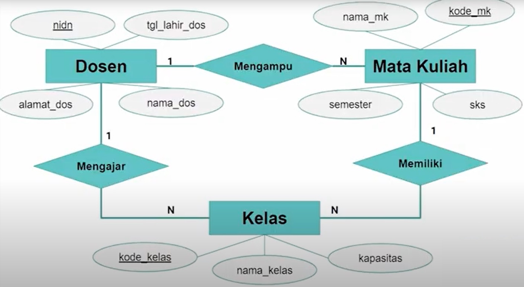

ERD dengan Ternary relationship

Studi Kasus yaitu Dosen – Mata Kuliah – Kelas.

- Relasi Dosen – Mata Kuliah (1–N).Satu dosen mengampu banyak mata kuliah. Implementasi: nidn (PK dari Dosen) menjadi foreign key di tabel Mata Kuliah.

Tabel Dosen

| NIDN | Nama | Tanggal_Lahir | Alamat |
| --- | --- | --- | --- |
| 01 | Dosen A | 01-01-1980 | Malang |
| 02 | Dosen B | 02-02-1982 | Surabaya |

Tabel Mata Kuliah

| Kode_MK | Nama_MK | SKS | Semester | NIDN |
| --- | --- | --- | --- | --- |
| STA623211 | Basis data | 3 | 3 | 01 |
| STA623205 | Analisis regresi | 3 | 3 | 01 |
| STA623209 | Komputasi Statistika | 3 | 3 | 02 |

- Relasi Dosen – Kelas (1–N). Satu dosen mengajar banyak kelas. Implementasi: nidn (PK dari Dosen) menjadi foreign key di tabel Kelas.

Tabel Kelas

| Kode_Kelas | Nama_Kelas | Kapasitas | NIDN |  |
| --- | --- | --- | --- | --- |
| A | 3A | 40 | 01 |  |
| B | 3B | 40 | 01 |  |
| A | 5A | 20 | 02 |  |

- Relasi Mata Kuliah – Kelas (1–N). Satu mata kuliah memiliki banyak kelas. Implementasi: kode_mk (PK dari Mata Kuliah) menjadi foreign key di tabel Kelas.

Tabel Kelas

| Kode_Kelas | Nama_Kelas | Kapasitas | NIDN | Kode_MK |  |
| --- | --- | --- | --- | --- | --- |
| A | 3A | 40 | 01 | STA623211 |  |
| B | 3B | 40 | 01 | STA623205 |  |
| A | 5A | 20 | 02 | STA623209 |  |

### Tugas

1. Buat ERD dan relation model dari relasi Program Studi yang memiliki pegawai dengan kardinalitas (1:N) yaitu satu Program Studi dapat memiliki banyak pegawai.
2. Buat ERD dan relation model dari relasi dosen yang membimbing skripsi mahasiswa dengan kardinalitas (N:N) yaitu satu dosen dapat membimbing banyak mahasiswa, dan satu mahasiswa dibimbing oleh dua orang dosen.

## Referensi

(Mastria 2022)

Mastria, Vida. 2022. “Knowledge Sharing.” Youtube. 2022. https://www.youtube.com/@KnowledgeSharingByVida.